# Question

The figure below shows 7 polygons on a $10\times10$ grid. The grid is composed of 100 squares, each with an area of 1. Each polygon’s area is labelled with an uppercase letter from $A$ to $G$.

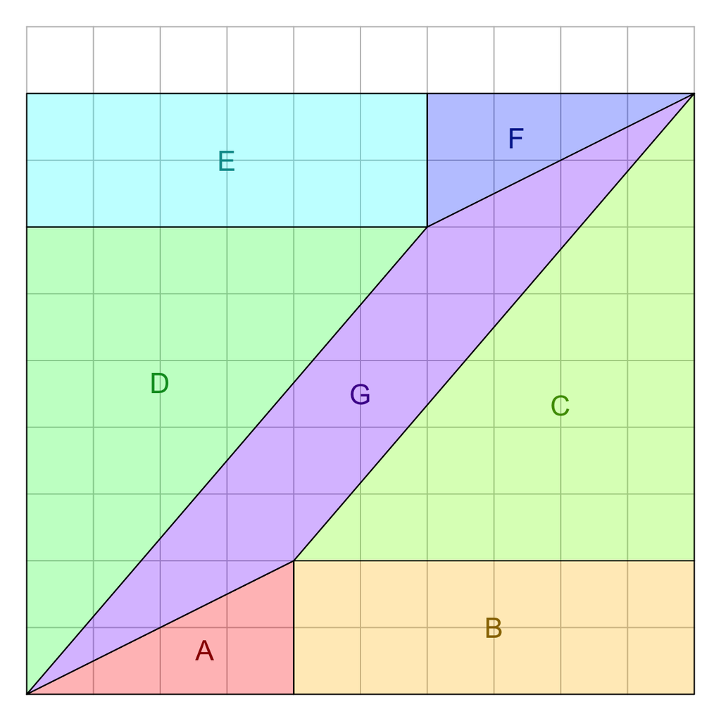

Find the areas of the triangles, rectangles, and parallelogram.

## Answerlist

- 1.5
- 2
- 2.5
- 3
- 3.5
- 4
- 11.5
- 12
- 12.5
- 13
- 13.5
- 14
- 21
- 21.5
- 22
- 22.5
- 23
- 23.5
- 19.5
- 20
- 20.5
- 21
- 21.5
- 22
- 12
- 12.5
- 13
- 13.5
- 14
- 14.5
- 1.5
- 2
- 2.5
- 3
- 3.5
- 4
- 13.5
- 14
- 14.5
- 15
- 15.5
- 16

# Solution

- Remember the area of a rectangle is width times height.
- Remember the area of a triangle is half of base times height.
  - For a right triangle, half the product of the legs.
- To find the area of the parallelogram, you can subtract all 6 other areas from the total area of the rectangle containing all 7 pieces.
- $a=4$
- $b=12$
- $c=21$
- $d=21$
- $e=12$
- $f=4$
- $g=16$

# Meta-information

extype: cloze exclozetype: schoice|schoice|schoice|schoice|schoice|schoice|schoice exsolution: 000001|010000|100000|000100|100000|000001|000001 exname: area_parallelogram